# Board Games

> Checking the ratings over time

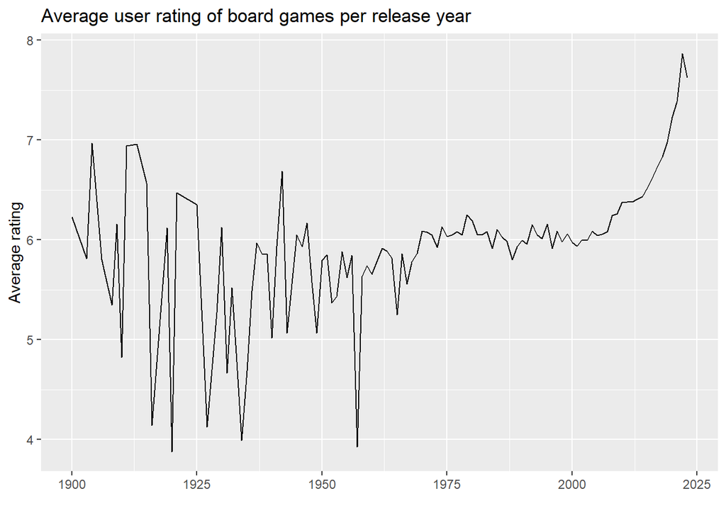

```r
modern %>%
  group_by(year) %>%
  summarise(avg_rating = mean(average),
            sum_users = sum(users_rated)) %>%
  ggplot(aes(x = year))+
  geom_line(aes(y = avg_rating))+
  labs(title = "Average user rating of board games per release year",
       y = "Average rating",
       x = "")
```

> Spread of ratings

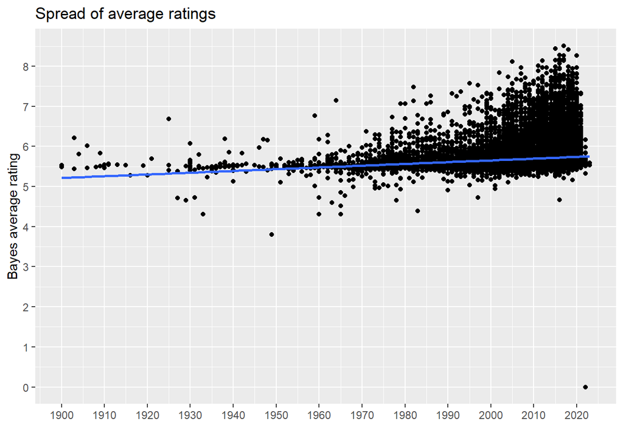

```r
modern %>%
  group_by(year) %>%
  ggplot(aes(x = year, bayes_average))+
  geom_point()+
  geom_smooth(method = lm, se = FALSE)+
  labs(title = "Spread of average ratings",
       y = "Bayes average rating",
       x = "")+
  scale_x_continuous(n.breaks = 10)+
  scale_y_continuous(n.breaks = 10)
```

> Joining the datasets

```r
# details <- details %>% mutate(across(boardgamecategory:boardgamepublisher, ~str_remove_all(., "[\\[\\]']")))
# Cleans up any square brackets and single quotes

details$boardgamecategory <- details$boardgamecategory %>% str_remove_all(., "[\\[\\]']")
joined <- rating %>% left_join(details, by = "id")
```

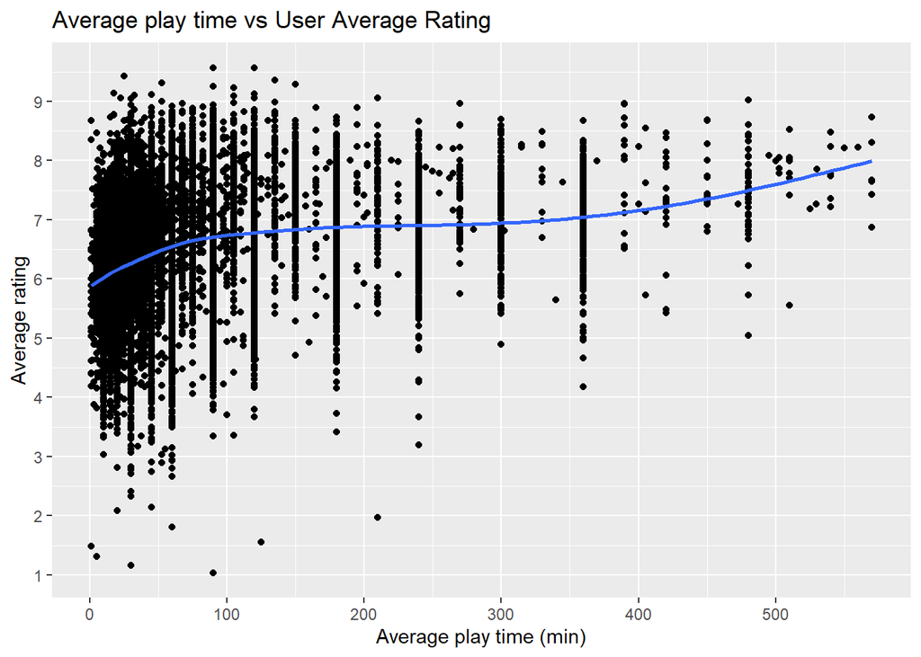

```r
joined %>%
  mutate(avgplaytime = (minplaytime + maxplaytime) / 2) %>%
  filter(avgplaytime < 600 & avgplaytime >= 1 & year > 1900) %>%
  # Because 10 hour game seems unreasonably long as well as keeping things to only "modern"
  ggplot(aes(x = avgplaytime, average))+
  geom_point()+
  geom_smooth(method = "gam", se = FALSE)+
  labs(title = "Average play time vs User Average Rating",
       y = "Average rating",
       x = "Average play time (min)")+
  scale_x_continuous(n.breaks = 6)+
  scale_y_continuous(n.breaks = 10)
```

We see that there are a lot more shorter games than longer games, which brings the average rating down

> Is there a difference in ratings depending on who owns the game compared to those that want or wish for it?

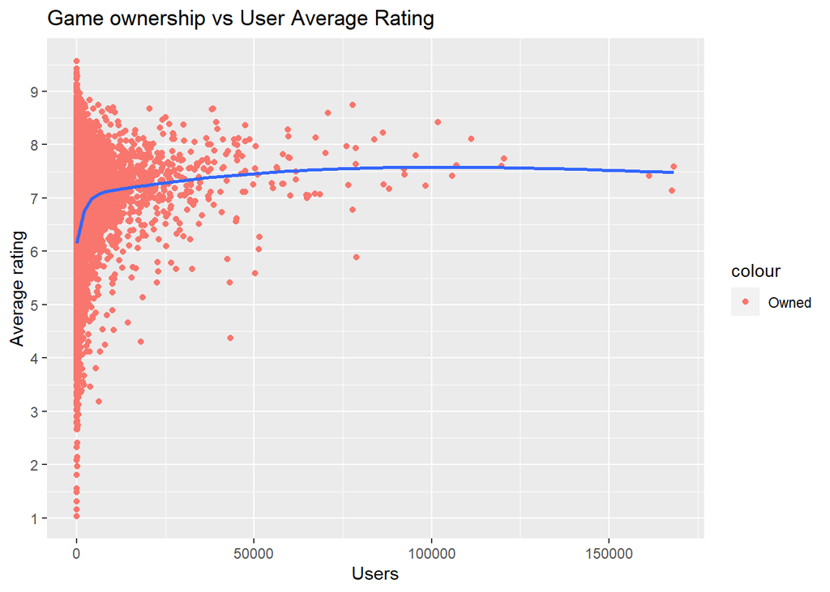

```r
joined %>%
  mutate(avgplaytime = (minplaytime + maxplaytime) / 2) %>%
  filter(avgplaytime < 1000 & avgplaytime >= 1 & year > 1900) %>%
  # Because 1000 min game seems unreasonably long as well as keeping things to only "modern"
  ggplot(aes(x = users_rated, y = average))+
  geom_point(aes(x = owned, color = "Owned"))+
  geom_smooth(aes(x = owned), se = FALSE)+
  labs(title = "Game ownership vs User Average Rating",
       y = "Average rating",
       x = "Users")+
  scale_x_continuous(n.breaks = 6)+
  scale_y_continuous(n.breaks = 10)
```

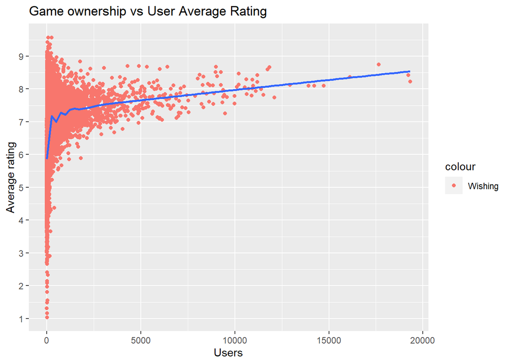

```r
joined %>%
  mutate(avgplaytime = (minplaytime + maxplaytime) / 2) %>%
  filter(avgplaytime < 1000 & avgplaytime >= 1 & year > 1900) %>%
  # Because 1000 min game seems unreasonably long as well as keeping things to only "modern"
  ggplot(aes(x = users_rated, y = average))+
  geom_point(aes(x = wishing, color = "Wishing"))+
  geom_smooth(aes(x = wishing), se = FALSE)+
  labs(title = "Game ownership vs User Average Rating",
       y = "Average rating",
       x = "Users")+
  scale_x_continuous(n.breaks = 6)+
  scale_y_continuous(n.breaks = 10)
```

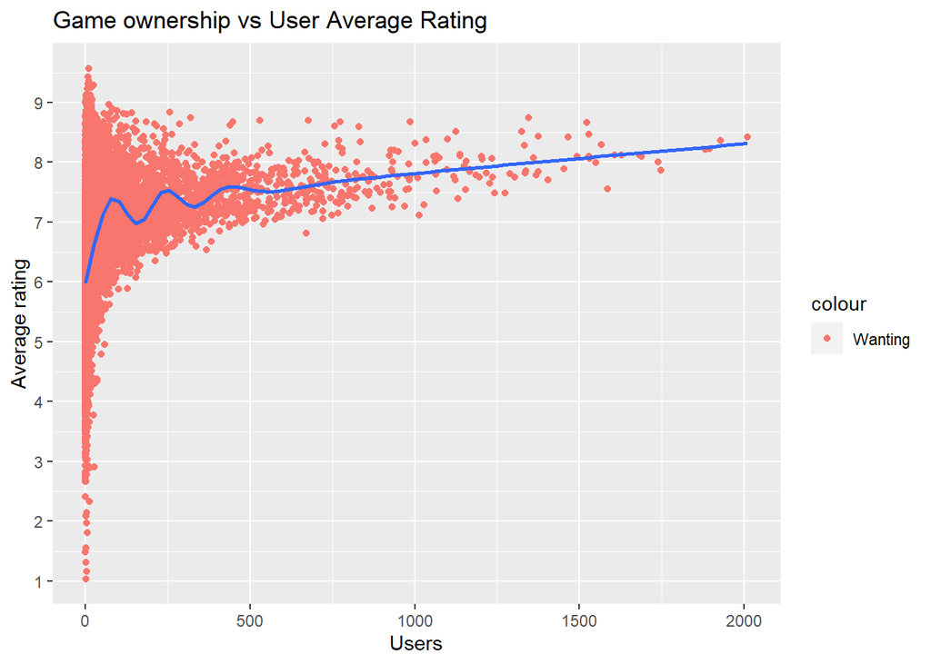

```r
joined %>%
  mutate(avgplaytime = (minplaytime + maxplaytime) / 2) %>%
  filter(avgplaytime < 1000 & avgplaytime >= 1 & year > 1900) %>%
  # Because 1000 min game seems unreasonably long as well as keeping things to only "modern"
  ggplot(aes(x = users_rated, y = average))+
  geom_point(aes(x = wanting, color = "Wanting"))+
  geom_smooth(aes(x = wanting), se = FALSE)+
  labs(title = "Game ownership vs User Average Rating",
       y = "Average rating",
       x = "Users")+
  scale_x_continuous(n.breaks = 6)+
  scale_y_continuous(n.breaks = 10)
```

People that do not own the game seem to rate games higher than those that own it

> Checking if category has an effect on ratings

```r
joinedsep <- joined %>% separate_rows(boardgamecategory, sep = ", ")
# Category are separated by commas, this puts them in different rows

top10category <- joinedsep %>%
  count(boardgamecategory) %>%
  arrange(desc(n)) %>%
  head(10)

# Get the top 10 most popular categories
```

> Overview of the top 10 categories

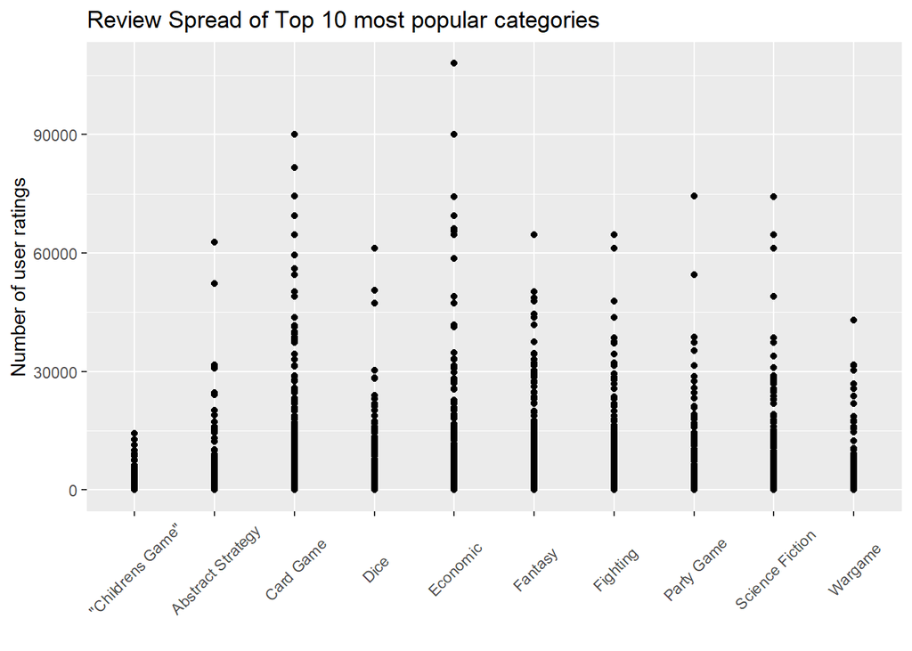

```r
joinedsep %>%
  filter(boardgamecategory %in% top10category$boardgamecategory) %>%
  group_by(boardgamecategory) %>%
  ggplot(aes(x = boardgamecategory, y = users_rated))+
  geom_point()+
  theme(axis.text.x = element_text(angle = 45, vjust = 0.5))+
  labs(title = "Review Spread of Top 10 most popular categories",
       x = "",
       y = "Number of user ratings")
```

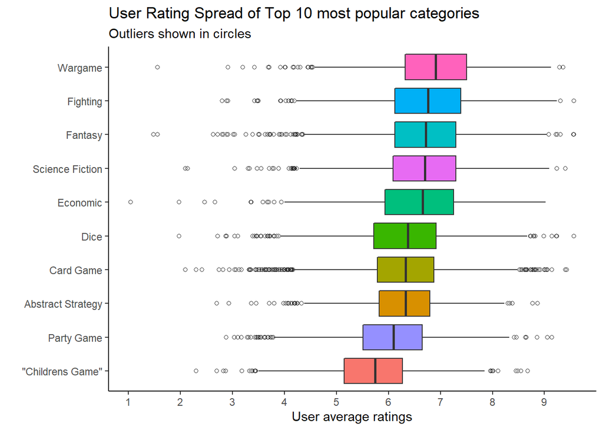

```r
joinedsep %>%
  filter(boardgamecategory %in% top10category$boardgamecategory) %>%
  group_by(boardgamecategory) %>%
  ggplot(aes(x = fct_reorder(boardgamecategory, average), y = average))+
  geom_boxplot(outlier.shape = 1, aes(fill = boardgamecategory))+
  labs(title = "User Rating Spread of Top 10 most popular categories",
       x = "",
       y = "User average ratings",
       subtitle = "Outliers shown in circles")+
  coord_flip()+
  scale_y_continuous(n.breaks = 11)+
  theme_classic()+
  theme(legend.position = "")
```

War games, Fighting, Fantasy, Sci-Fi and Economic games average higher than the rest of the top 10 categories

> Checking differences based on game ownership

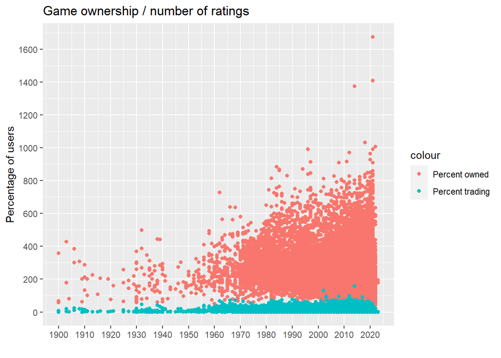

```r
pct_joined <- joined %>%
  filter(year >= 1900) %>%
  group_by(id) %>%
  mutate(pct_owned = (owned / users_rated) * 100,
         pct_want = (wanting / users_rated) * 100,
         pct_trading = (trading / users_rated) * 100,
         pct_wishing = (wishing / users_rated) * 100)

ggplot(pct_joined, aes(x = year))+
geom_point(aes(y = pct_owned, color = "Percent owned"))+
  geom_point(aes(y = pct_trading, color = "Percent trading"))+
  scale_x_continuous(n.breaks = 10)+
  labs(y = "Percentage of users",
       x = "",
       title = "Game ownership / number of ratings")+
  scale_y_continuous(n.breaks = 12)
```

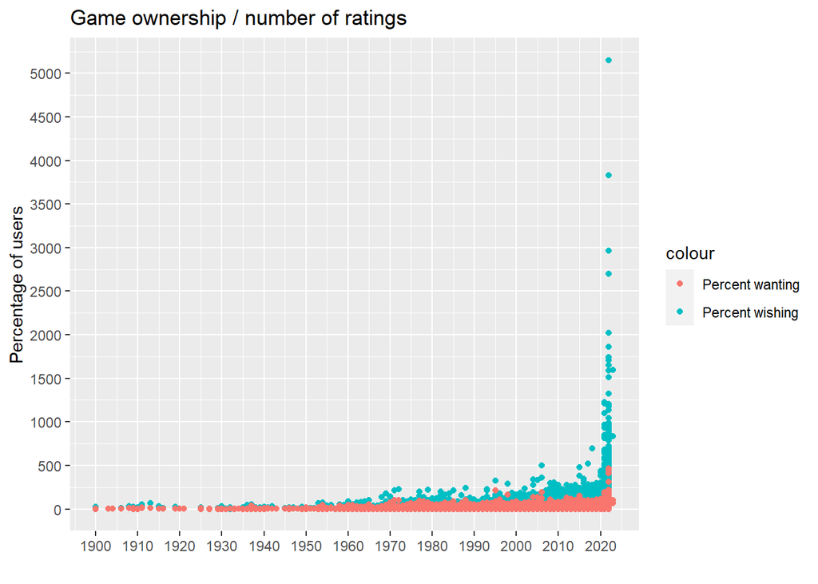

```r
ggplot(pct_joined, aes(x = year))+
geom_point(aes(y = pct_wishing, color = "Percent wishing"))+
  geom_point(aes(y = pct_want, color = "Percent wanting"))+
  scale_x_continuous(n.breaks = 10)+
  labs(y = "Percentage of users",
       x = "",
       title = "Game ownership / number of ratings")+
  scale_y_continuous(n.breaks = 12)
```

There are a lot points that are over 100 percent especially in the wishing and owning categories which can state that reviewers are more likely to state their ownership of a game rather than rate it

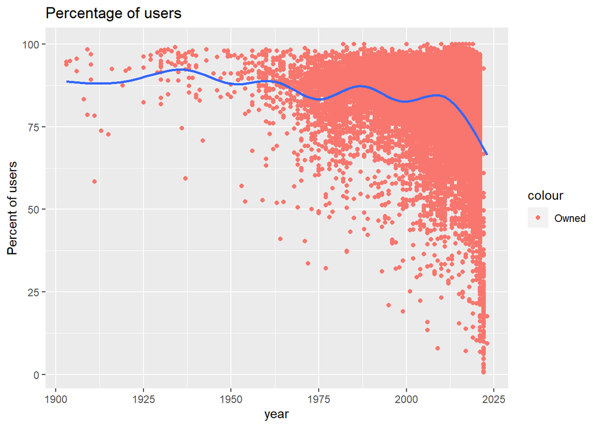

```r
detailspct <- joined %>%
  group_by(id) %>%
  mutate(total_users = sum(owned + trading + wanting + wishing)) %>%
  mutate(pct_owned = owned / total_users * 100,
         pct_trading = trading / total_users * 100,
         pct_wanting = wanting / total_users * 100,
         pct_wishing = wishing / total_users * 100)

detailspct %>%
  filter(year > 1900) %>%
  group_by(year) %>%
  ggplot(aes(x = year))+
    geom_point(aes(y = pct_owned, color = "Owned"))+
  labs(title = "Percentage of users",
       y = "Percent of users")+
  geom_smooth(aes(y = pct_owned), se = FALSE)
```

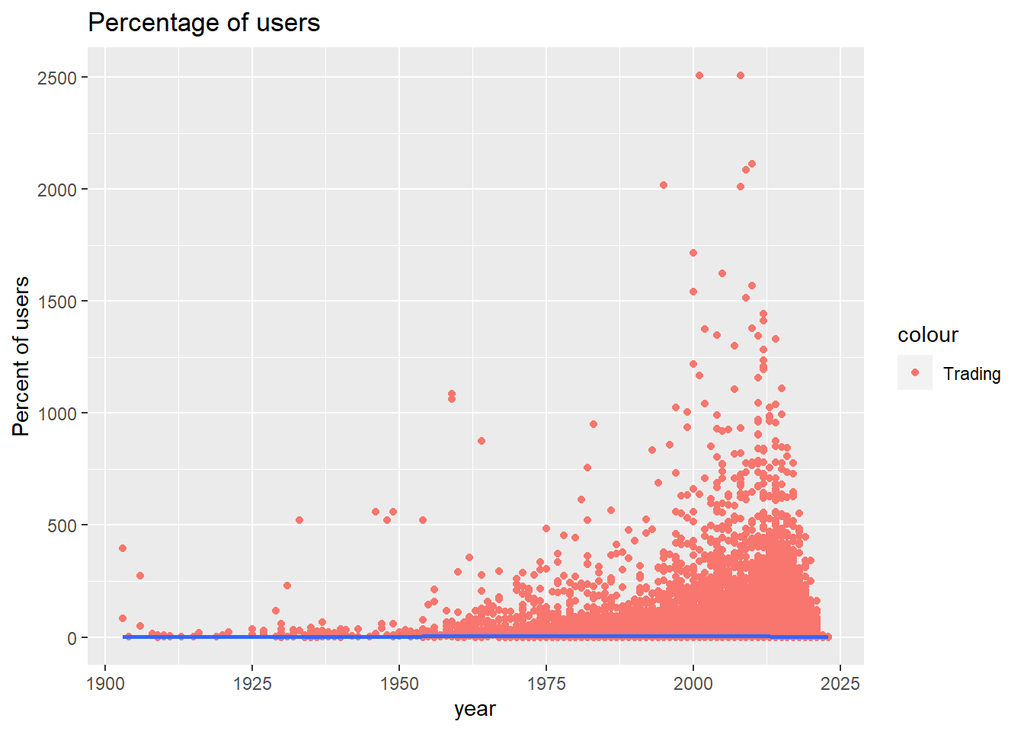

```r
detailspct %>%
  filter(year > 1900) %>%
  group_by(year) %>%
  ggplot(aes(x = year))+
    geom_point(aes(y = trading, color = "Trading"))+
  labs(title = "Percentage of users",
       y = "Percent of users")+
  geom_smooth(aes(y = pct_trading), se = FALSE)
```

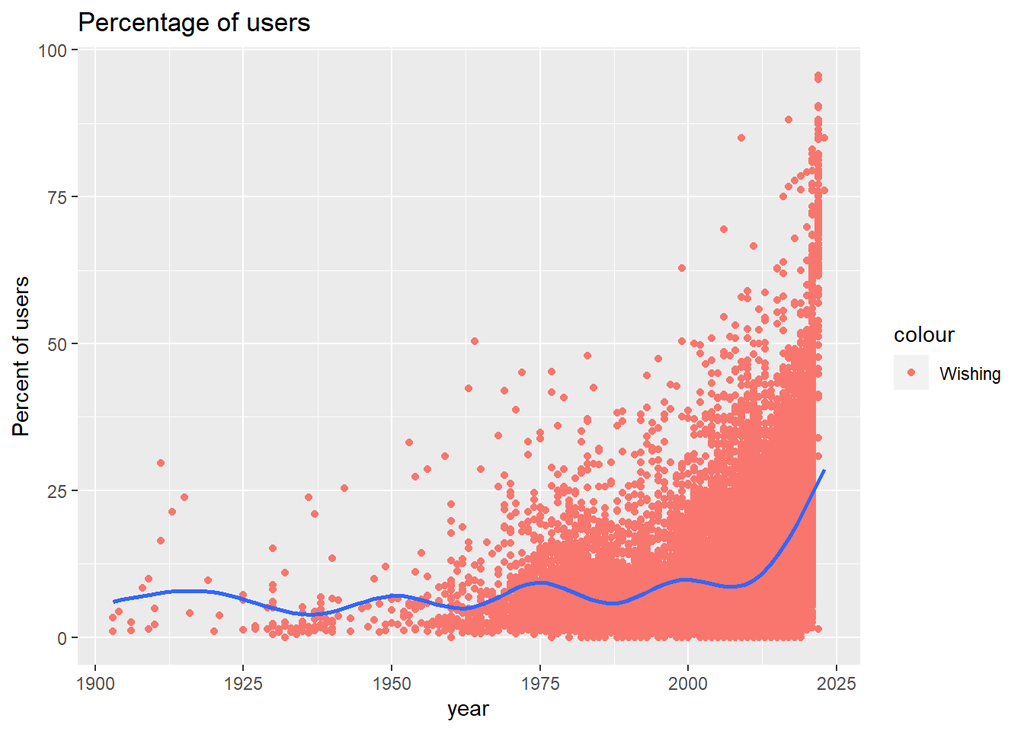

```r
detailspct %>%
  filter(year > 1900) %>%
  group_by(year) %>%
  ggplot(aes(x = year))+
    geom_point(aes(y = pct_wishing, color = "Wishing"))+
  labs(title = "Percentage of users",
       y = "Percent of users")+
  geom_smooth(aes(y = pct_wishing), se = FALSE)
```

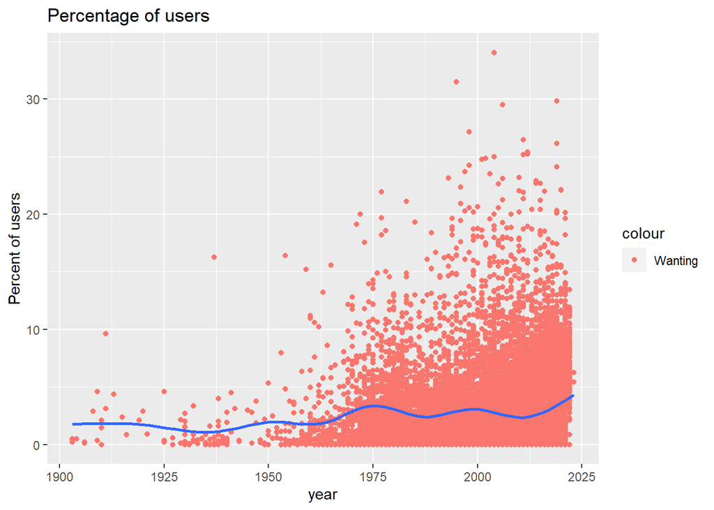

```r
detailspct %>%
  filter(year > 1900) %>%
  group_by(year) %>%
  ggplot(aes(x = year))+
    geom_point(aes(y = pct_wanting, color = "Wanting"))+
  labs(title = "Percentage of users",
       y = "Percent of users")+
  geom_smooth(aes(y = pct_wanting), se = FALSE)
```

These 4 plots here calculate the percentage of users that own/trading/want/wishing for the game. We see that as newer games come out, less people own them and more people more people want them i.e. lower supply higher demand